# c02 · Advanced Visualization with ggplot2

Advanced R for Data Analysis and Reporting

Johann-Friedrich Salzmann

## What’s in this module

- The grammar of graphics
- Standard plots: scatter, line, bar, histogram, density, boxplot
- Groups, colours, facets
- Scales, labels, themes, a custom theme
- Multi-plots with patchwork, exporting, interactive plots with plotly

## Why ggplot2

- One consistent system instead of one function per chart type
- Built in layers: add, remove, change one part at a time
- Publication-ready defaults, huge ecosystem
- Same logic as matplotlib’s object API or plotnine (a Python ggplot2 port)

## The grammar of graphics

- **data**: a long tibble
- **aes**: column → x, y, colour, …
- **geom**: how to draw
- **scales**, **facets**, **theme**, **labs**

```r
yearly |>
  ggplot(aes(x = year, y = temp_mean)) +
  geom_line(color = "grey60") +
  geom_point() +
  geom_smooth(method = "loess") +
  labs(title = "Mean temperature") +
  theme_minimal()
```

## Layers

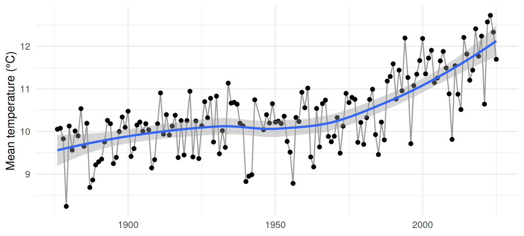

## Standard plot types

| Question | Geom |
| --- | --- |
| relation of two variables | `geom_point()` |
| development over time | `geom_line()` (+ `geom_point()`) |
| amounts per category | `geom_col()`, `geom_bar()` |
| distribution | `geom_histogram()`, `geom_density()`, `geom_boxplot()` |
| trend | `geom_smooth()` |

## Groups and facets

- `aes(color = season)`: one line per group, with a legend
- `facet_wrap(~ season)`: one panel per group, same axes
- `scales = "free_y"`: each panel its own y axis

## Scales and labels

```r
scale_color_manual(values = season_colors)
scale_fill_gradient2(low = "#2166AC", mid = "white", high = "#B2182B")
scale_y_continuous(labels = label_number(suffix = " °C", style_positive = "plus"))
labs(title = ..., subtitle = ..., x = ..., y = ..., caption = ...)
```

## Showcase: warming stripes

[figure not shown]

Karlsruhe 1876–2025, deviation from the 1961–1990 mean. After Ed Hawkins.

## Themes: one function for every plot

```r
theme_report <- function(base_size = 12) {
  theme_minimal(base_size = base_size) +
    theme(
      plot.title = element_text(face = "bold"),
      panel.grid.minor = element_blank(),
      legend.position = "bottom"
    )
}

my_plot + theme_report()
theme_set(theme_report())  # default for all plots
```

## Multi-plots with patchwork

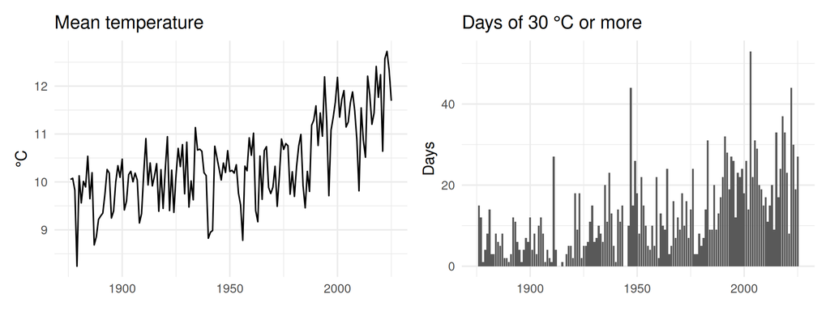

`temp_plot + hot_plot` side by side, `/` stacked, `&` applies to all

## Exporting

```r
ggsave("anomaly.pdf", plot = anomaly_plot, width = 16, height = 9, units = "cm")
ggsave("anomaly.png", plot = anomaly_plot, width = 16, height = 9, units = "cm", dpi = 300)
```

- Save at the size you print at: text sizes are absolute
- PDF/SVG for print (vector), PNG at 300 dpi for slides and web

## Interactive: `ggplotly()`

```r
p_load(plotly)
ggplotly(seasonal_plot)
```

- hover, zoom, toggle groups
- HTML only (Quarto HTML reports, Shiny), not PDF

## Practice

- Work through `c02/c02_classroom.R`
- Try it: hot days per decade; summer maxima then vs. now